# TRECVID 2026

Video question answering, traced through one question

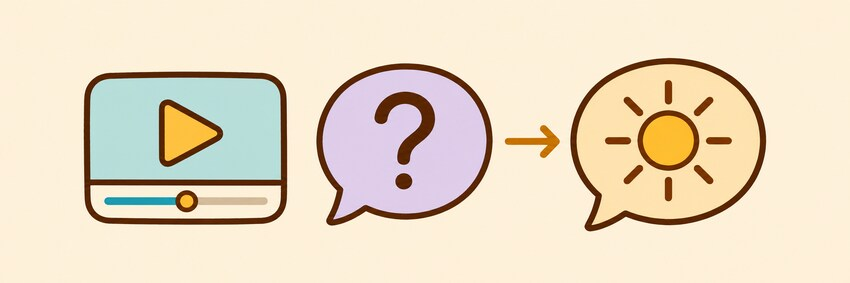

Nidhin Pattaniyil · Tanwir Zaman · Semih Yagli — NP Labs

## What we will walk through

1. The video question
2. Answer generation
3. Multiple choice
4. Conclusion

Two tasks traced through one weather clip.

## Two outputs from the same video question

The TRECVID VQA task

**Video + question**

**Generate answers**Write ten ranked answerse.g. “It is sunny.”

**Rank the choices**Order the supplied choicese.g. Sunny → Cloudy → Rainy

## The video question we’ll follow

Q1835 · Video frame at 2 s

“What is the weather like when someone is filming the white building?”

Official multiple-choice answer **Sunny**

## Answer generation

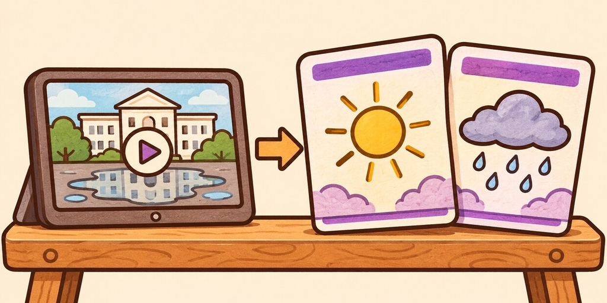

What can the model infer from the clip?

## Four ways to give a model the same clip

### 12 sampled frames → Qwen3.5-4B

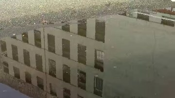

0.21 s

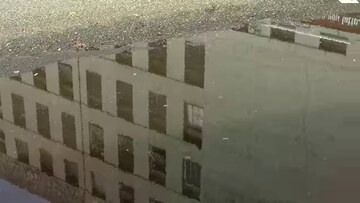

0.63 s

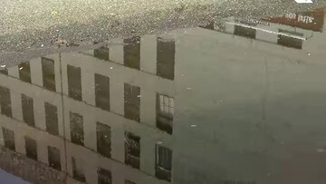

1.04 s

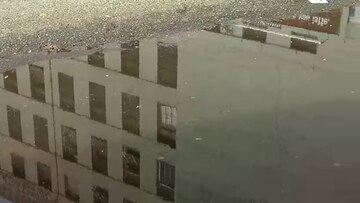

1.46 s

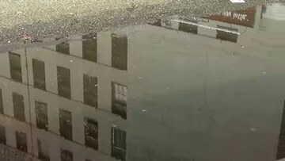

1.88 s

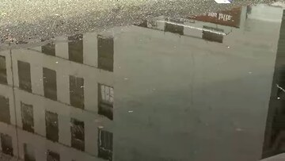

2.30 s

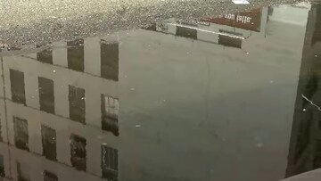

2.71 s

[figure not shown]

3.13 s

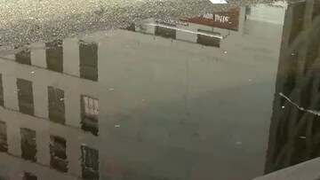

3.55 s

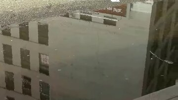

3.97 s

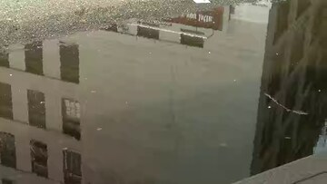

4.39 s

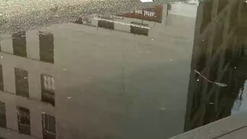

4.80 s

Q1835 · Video frame at 2 s

**Video without transcript**

Qwen3.6-27B

**Video + Whisper transcript**

Qwen3.6-27B

**Video + original audio**

Gemini 3.7 Flash

## Same clip, different generated answers

Q1835 · View video frame

Qwen3.5-4B · 12 sampled frames**“rainy”**

Qwen3.6-27B · video without transcript**“It's sunny.”**

Qwen3.6-27B · video + Whisper transcript**“Sunny”**

Gemini 3.7 Flash · video + original audio**“It is sunny.”**

## Answer-generation examples

Model answers and METEOR scores

### Named the activity

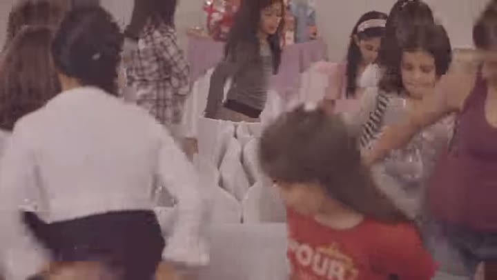

Q1744 · Video frame at 4 s

What are the children playing?

**Qwen3.5-4B · frames**

“dolls”0.000

**Qwen3.6-27B · video**

“Dance”0.000

**Qwen3.6-27B + Whisper**

“Dance”0.000

**Gemini 3.7 Flash**

“Musical chairs”0.938

### Put the wrong count first

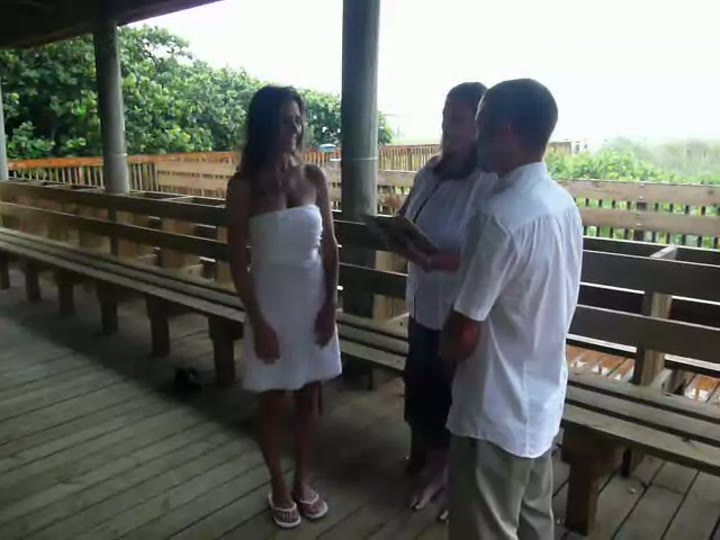

Q120 · Video frame at 2 s

How many people are talking near the bench?

**Qwen3.5-4B · frames**

“3”0.500

**Qwen3.6-27B · video**

“3”0.500

**Qwen3.6-27B + Whisper**

“3”0.500

**Gemini 3.7 Flash**

“2”0.000

Qwen video + Whisper supplied “3” at rank 2.

**First-answer METEOR across 2,428 questions** · Gemini-first scored higher on 1,738, lower on 529, and tied on 161.

## More generated answers

Model answers and METEOR scores

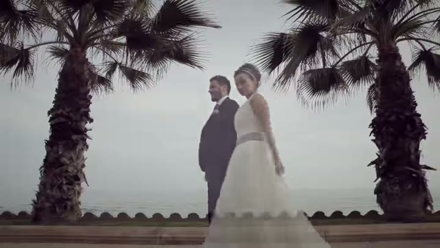

Q1 · Video frame at 2.5 s

What happens to the image of the bride and groom?

**Qwen3.5-4B · frames**

“It fades away.”0.852

**Qwen3.6-27B · video**

“The image of the bride and groom fades away.”0.270

**Qwen3.6-27B + Whisper**

“It fades away.”0.852

**Gemini 3.7 Flash**

“The image of the bride and groom fades out and disappears as they walk between the palm trees.”0.217

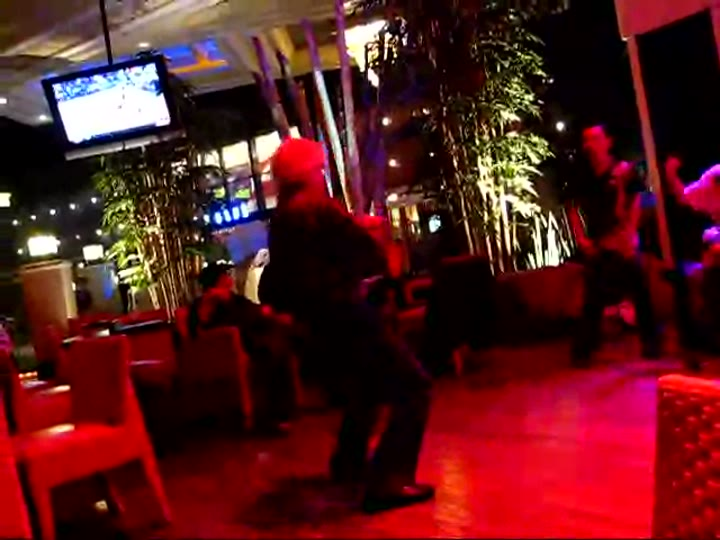

Q2181 · Video frame at 4 s

What are the men doing across from each other?

**Qwen3.5-4B · frames**

“dancing”0.179

**Qwen3.6-27B · video**

“dancing”0.179

**Qwen3.6-27B + Whisper**

“dancing”0.179

**Gemini 3.7 Flash**

“They are dancing.”0.992

## Speech in the video

[figure not shown]

Q448 · Video frame at 4 s

**Whisper transcript summary**

Whisper picked up a motivational speech about passion, goals, and determination.

What can be heard coming from the large screen?

Model answers and METEOR scores

**Qwen3.5-4B · frames**

“Speech”0.000

**Qwen3.6-27B · video**

“music”0.000

**Qwen3.6-27B + Whisper**

“A man's voice.”0.976

**Gemini 3.7 Flash**

“A man giving a speech can be heard.”0.185

## Reading a number on screen

[figure not shown]

Q1573 · Video frame at 2.2 s

What is the number on the side of the building?

Model answers and METEOR scores

**Qwen3.5-4B · frames**

“3”0.500

**Qwen3.6-27B · video**

“7”0.000

**Qwen3.6-27B + Whisper**

“10”0.000

**Gemini 3.7 Flash**

“The number on the side of the building is 3.”0.250

## Answer-generation results

**STS** · sentence meaning **METEOR** · word matches and order **BERTScore** · word meaning in context

All scores compare the first generated answer with reference answers.

Weather example · Q1835

| First answer | STS | METEOR | BERTScore |
| --- | --- | --- | --- |
| “rainy” | 0.552 | 0.000 | 0.999 |
| “Sunny” | 1.000 | 0.500 | 1.000 |
| “It is sunny.” | 1.000 | 0.992 | 1.000 |

Same sunny meaning, different METEOR scores · 0.500 vs. 0.992

Full test set · first-answer scores and ranks out of 44

| Run | STS | METEOR | BERTScore |
| --- | --- | --- | --- |
| Open-weight Qwen · 12 frames | 0.4856 · 17th | 0.1705 · 44th | 0.8907 · 22nd |
| Open-weight Qwen · transcript first | 0.4658 · 28th | 0.1886 · 41st | 0.8916 · 19th |
| Gemini-first · Qwen alternatives | 0.4845 · 19th (tie) | 0.3182 · tied 2nd | 0.8789 · tied 39th |

**STS tie:** Our Gemini-first and rewritten runs shared 19th place at 0.484527. See the STS leaderboard.

**1st of 44** on METEOR Best@5 after rewriting the list, with all references.

## Multiple-choice ranking

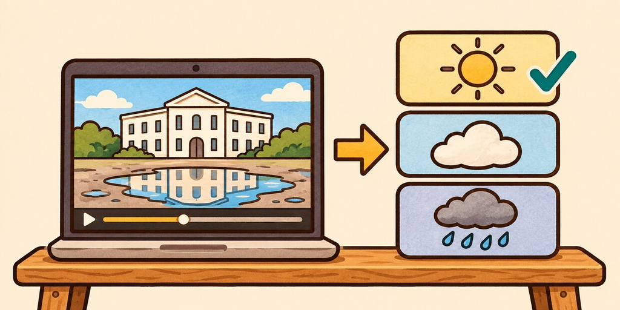

Same video. Rank the supplied choices.

## The same video, now with answer choices

Q1835 · View video frame

Organizer’s eight choices

- Sunny
- Partly cloudy
- Cloudy
- Windy
- Foggy
- Rainy
- Stormy
- Snowy

Top-choice accuracy gives credit for the organizer’s designated option.

## Gemini ranked “Rainy” first

Match our Gemini-first answer · our best first-answer METEOR **“It is sunny.” + supplied choices**→ **✓ 1. Sunny**

Gemini 3.7 Flash · Rank supplied choices from video

**Video + question + supplied choices**

→

**1. Rainy**Sunny was 7th

Q1835 · official choice **Sunny**

## Gemini ranked the deep-rut answer first

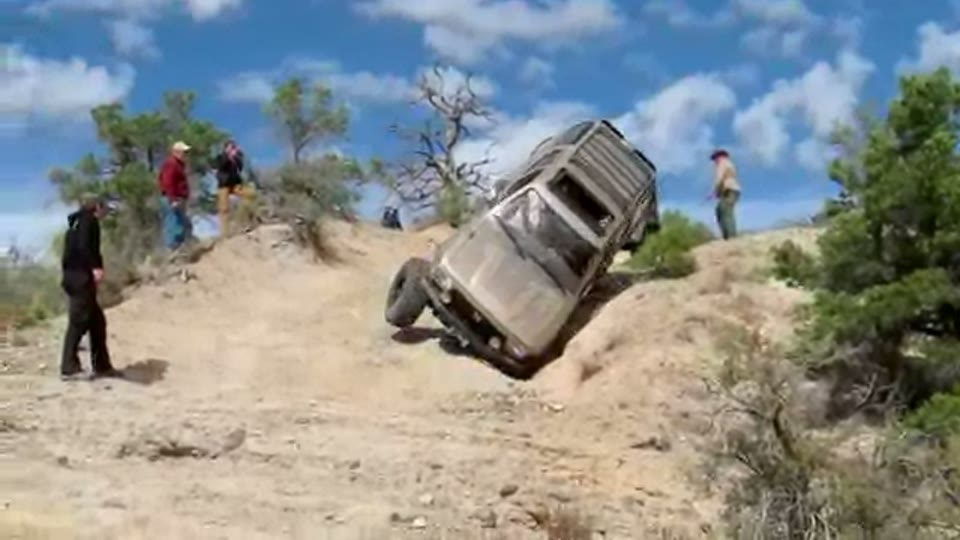

Q447 · Video frame at 2 s

“What is the person in the four-wheel drive vehicle trying to do?”

Match our Gemini-first answer**“Trying to climb the hillside”**

Gemini 3.7 Flash · Rank supplied choices from video**✓ “Trying to safely get out of a deep rut”**Official choice

## Two more cases where video changed the answer

### Gemini fixed the answer

[figure not shown]

Q25 · Video frame at 2.4 s

What is the man adjusting?

**Match our Gemini-first answer**

A still camera

**Gemini ranks from video**

✓ A video camera

### Gemini missed the answer

[figure not shown]

Q576 · Video frame at 5.2 s

How many types of flags are being held by the people?

**Match our Gemini-first answer**

✓ 2

**Gemini ranks from video**

1

✓ Organizer’s correct choice.

## More multiple-choice examples

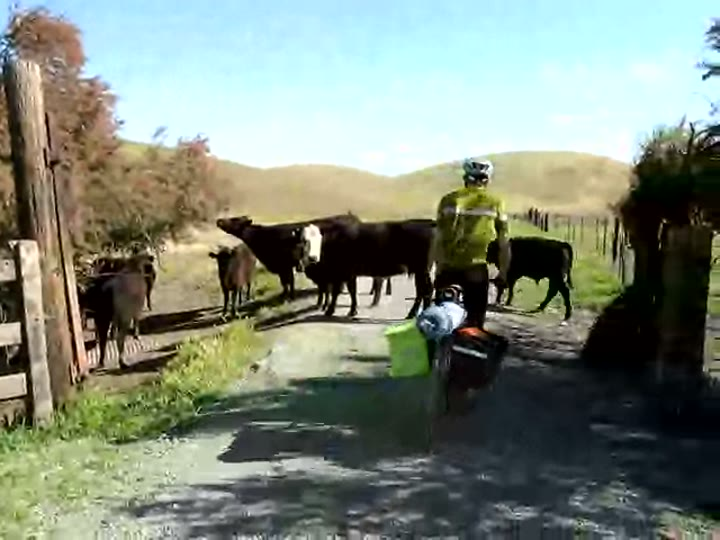

Q109 · Gemini matched the scoring key · frame at 3 s

What is the bicyclist likely doing with the cattle?

**Match our Gemini-first answer**

He is herding them

**Gemini ranks from video**

✓ He is stopping because they are blocking the road

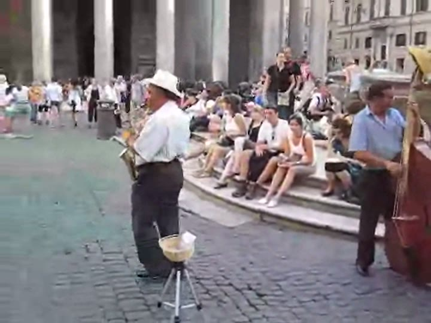

Q55 · Answer matching matched the scoring key · frame at 7 s

What are people doing in the town square?

**Match our Gemini-first answer**

✓ They are walking and standing

**Gemini ranks from video**

They are sitting

✓ Organizer’s correct choice.

## Same count, different score

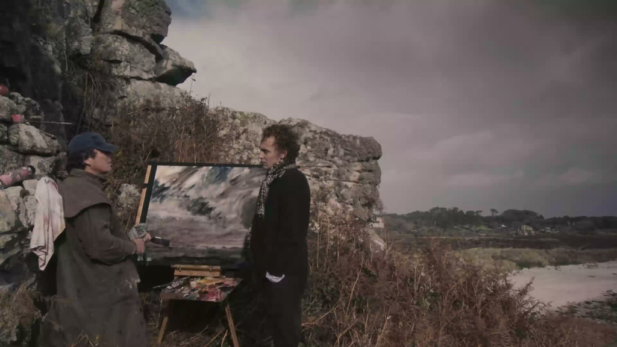

Q2049 · frame at 50 seconds

How many people in the video are wearing a hat?

**Scored correct**

✓ “One”

**All four runs chose**

“One person is wearing a hat”

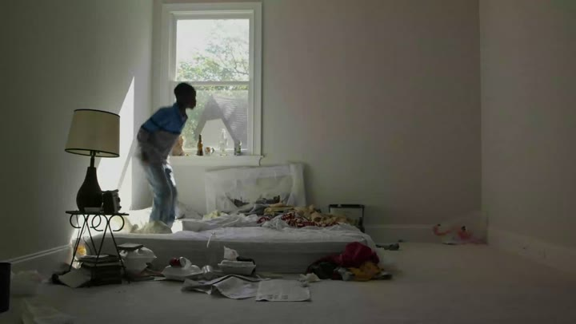

Q1369 · frame at 11 seconds

How many beds are in the house?

**Scored correct**

✓ “One”

**All four runs chose**

“One bed”

In both questions, the scorer gave credit to “One.”

## Multiple-choice results

**Gemini ranked 2nd of 42** on top-choice accuracy.

**Match our Gemini-first answer****78.748%**

**Gemini 3.7 Flash · Rank from video****84.514%**

**140 more correct**219 fixed · 79 lostTop-choice accuracy · 2,428 scored questions

## Conclusion

### Answer generation

- Qwen on 12 sampled frames
- Qwen on video with and without Whisper
- Gemini on video and audio
- **First-answer METEOR** · wording match to references  
  Gemini-first · **0.3182 · tied 2nd of 44 runs**

### Multiple choice

**Top-choice accuracy** · first choice correct

- Match Gemini’s saved answer  
  **78.7% correct**
- Ask Gemini to rank choices from video  
  **84.5% correct · 2nd of 42 runs**

## Appendix

## The four answer-generation approaches

What goes inModel 12 sampled frames→

[figure not shown]

3.5-4B Video + Whisper transcript→

[figure not shown]

3.6-27B Video without transcript→

[figure not shown]

3.6-27B Video + audio→

[figure not shown]

3.7 Flash

## How we filled ten answer slots

Frame baseline · AG1**12 frames**→**Ask Qwen for ten answers**

Combined runs · AG2 and AG3**One answer per model call**→**Fill remaining slots from AG1**

## Three ways to assemble the answers

Q1835**Weather at the white building**

AG1

### Frames only

10 answers from Qwen

1. 1rainy
2. 2overcast
3. 3cloudy
4. 4hazy

AG2

### Transcript first

2 single answers + 8 from AG1

1. 1Sunny
2. 2It's sunny.
3. 3rainy
4. 4overcast

AG3

### Gemini first

3 single answers + 7 from AG1

1. 1It is sunny.
2. 2Sunny
3. 3It's sunny.
4. 4rainy

First four submitted answers per run

## AG4 · An experimental rewrite of saved answers

Q1835**Weather at the white building**

Group the saved answers

Sunny“It is sunny.” · “Sunny” · “It’s sunny.”

Rainy“rainy”

→

Rewrite and rank

1. 1It is sunny.
2. 2rainy
3. 3Sunny
4. 4It's sunny.
5. 5The weather is rainy.

Rank 1 stays fixed · rank 5 is a new wording · all ten answers

## AG4’s ten answers for the weather clip

Q1835**Rank 1 stays fixed**

1. 1It is sunny.
2. 2rainy
3. 3Sunny
4. 4It's sunny.
5. 5The weather is rainy.
6. 6The weather is sunny.
7. 7It is raining.
8. 8Bright and sunny.
9. 9Rainy weather.
10. 10Sunny weather.

Sunny group · Rainy group

## The best run depends on the metric

STS@1**AG1**0.48617th of 44

METEOR@1**AG3 / AG4**0.318Tied 2nd of 44

BERTScore F1@1**AG2**0.89219th of 44

Highest-scoring NP Labs run for each metric · all references

## Official leaderboard

Published NP Labs results and ranks

| Metric | Best NP Labs run | NP Labs place |
| --- | --- | --- |
| First-answer STS | Qwen frames **0.4856** | 17th of 44 |
| First-answer METEOR | Rewritten list / Gemini-first **0.3182** | Tied 2nd of 44 |
| First-answer BERTScore F1 | Qwen transcript first **0.8916** | 19th of 44 |
| METEOR Best@5 | Rewritten list **0.4347** | 1st of 44 |
| Multiple-choice accuracy | Gemini ranks from video **84.514%** | 2nd of 42 |

Best@5 scores the highest-scoring answer among the first five. Answer generation · Multiple choice

## Answer-generation leaderboard

NP Labs entries · First-answer scores using all references · ranks among 44 runs

| Run | STS | METEOR | BERTScore F1 |
| --- | --- | --- | --- |
| AG1 | 0.485552 (17) | 0.170537 (44) | 0.890737 (22) |
| AG2 | 0.465828 (28) | 0.188578 (41) | 0.891633 (19) |
| AG3 | 0.484527 (19=) | 0.318244 (2=) | 0.878867 (39=) |
| AG4 | 0.484527 (19=) | 0.318244 (2=) | 0.878867 (39=) |

[Scoring tables in the paper](https://npatta01.github.io/trec_video_2026/docs/paper/trecvid2026.pdf#page=3) · = marks a tie.

## Multiple-choice leaderboard

NP Labs entries · Top-choice accuracy · ranks among 42 runs

| Run | Correct | Accuracy | Rank |
| --- | --- | --- | --- |
| MC1 | 1,912 | 78.748% | 26 |
| MC2 | 2,025 | 83.402% | 8 |
| MC3 | 2,052 | 84.514% | 2 |
| MC4 | 2,047 | 84.308% | 3= |

[Scoring tables in the paper](https://npatta01.github.io/trec_video_2026/docs/paper/trecvid2026.pdf#page=3) · = marks a tie.

## STS leaderboard

NP Labs entries · First-answer STS · ranks among 44 runs

| Place | Submitted run | STS |
| --- | --- | --- |
| 17 | NP Labs · Qwen frames | 0.485552 |
| 19 (tie) | NP Labs · Rewrite the answer list | 0.484527 |
| 19 (tie) | NP Labs · Gemini-first | 0.484527 |
| 28 | NP Labs · Qwen transcript first | 0.465828 |

The two NP Labs runs with 0.484527 share 19th place. Back to answer-generation results.

## Where each ranker put “Sunny”

Q1835**Official choice · Sunny**

**Rank**12345678

**MC1 · Match saved answer**AG3 text + choices

Sunny·······

**MC2 · Selectively use video**Text check → choose ranking

Sunny·······

**MC3 · Rank from video**Gemini 3.7

Rainy·····Sunny·

**MC4 · Rank from video**Gemini 3.8

Sunny·······

## Direct video ranking gave our best result

MC1 · Match answer**78.748%**

MC2 · Selective video**83.402%**

MC3 · Gemini 3.7 video**84.514%**

MC4 · Gemini 3.8 video**84.308%**

84.514%  
MC3 accuracy

**2nd of 42 runs**

+140 correct vs. MC1

Official test set · 2,428 questions

## Direct video fixed 219 answers and lost 79

**Wrong → right****219**

**Right → wrong****79**

**+140**net correctMC3 versus MC1 · same 2,428 questions

## MC2 replaced 786 rankings

Text checker**798 flagged**

→

**786**Used MC3 ranking

**12**Kept MC1 ranking

## How generated answers are scored

Saved first answer**“It is sunny.”**

→

Compare with reference answers**Meaning and wording**STS · METEOR · BERTScore

Weather example · METEOR@1 “Sunny” **0.500** “It is sunny.” **0.992**

## The three metrics score the same answers differently

| First answer | STS | METEOR | BERTScore F1 |
| --- | --- | --- | --- |
| rainy | 0.552 | 0.000 | 0.999 |
| Sunny | 1.000 | 0.500 | 1.000 |
| It is sunny. | 1.000 | 0.992 | 1.000 |

## The transcript helped on the development set

**12 frames****9 / 30**

**+ Whisper text****11 / 30**

Exact matches · same Qwen3.5-4B model · 30 labeled 2025 questions